# 310657002_林奕勳_hw05-for-mpg-data

Code coming from https://www.data-to-viz.com/caveat/boxplot.html

```r
library('tidyverse')
```

```r
library(ggplot2)
library(tidyr)
library(dplyr)
library(moments)
library(viridis)
feature_name_mpg = c('mpg','cylinders','displacement','horsepower','weight','acceleration','model year','origin','car name')
data_mpg = read.table("C:\\Users\\xx958\\OneDrive\\桌面\\nycu 碩一_上\\數據科學\\mpg\\auto-mpg.data",head=F,col.names=feature_name_mpg)
data_mpg = data_mpg[1:8]

str(data_mpg)
```

```
## 'data.frame':    398 obs. of  8 variables:
##  $ mpg         : num  18 15 18 16 17 15 14 14 14 15 ...
##  $ cylinders   : int  8 8 8 8 8 8 8 8 8 8 ...
##  $ displacement: num  307 350 318 304 302 429 454 440 455 390 ...
##  $ horsepower  : chr  "130.0" "165.0" "150.0" "150.0" ...
##  $ weight      : num  3504 3693 3436 3433 3449 ...
##  $ acceleration: num  12 11.5 11 12 10.5 10 9 8.5 10 8.5 ...
##  $ model.year  : int  70 70 70 70 70 70 70 70 70 70 ...
##  $ origin      : int  1 1 1 1 1 1 1 1 1 1 ...
```

```r
# it is show that have 398 datas and 8 variables(mpg is label orthers is feature)
dim(data_mpg)
```

```
## [1] 398   8
```

## change type of data to numerice but probuct NA

```r
for (i in names(data_mpg)){
  data_mpg[[i]]=as.numeric(data_mpg[[i]])
}
summary(data_mpg)
```

```
##       mpg          cylinders      displacement     horsepower        weight
##  Min.   : 9.00   Min.   :3.000   Min.   : 68.0   Min.   : 46.0   Min.   :1613
##  1st Qu.:17.50   1st Qu.:4.000   1st Qu.:104.2   1st Qu.: 75.0   1st Qu.:2224
##  Median :23.00   Median :4.000   Median :148.5   Median : 93.5   Median :2804
##  Mean   :23.51   Mean   :5.455   Mean   :193.4   Mean   :104.5   Mean   :2970
##  3rd Qu.:29.00   3rd Qu.:8.000   3rd Qu.:262.0   3rd Qu.:126.0   3rd Qu.:3608
##  Max.   :46.60   Max.   :8.000   Max.   :455.0   Max.   :230.0   Max.   :5140
##                                                  NA's   :6
##   acceleration     model.year        origin
##  Min.   : 8.00   Min.   :70.00   Min.   :1.000
##  1st Qu.:13.82   1st Qu.:73.00   1st Qu.:1.000
##  Median :15.50   Median :76.00   Median :1.000
##  Mean   :15.57   Mean   :76.01   Mean   :1.573
##  3rd Qu.:17.18   3rd Qu.:79.00   3rd Qu.:2.000
##  Max.   :24.80   Max.   :82.00   Max.   :3.000
##
```

## find NA , and horsepower have 6 NA Missing value

```r
colSums(is.na(data_mpg))
```

```
##          mpg    cylinders displacement   horsepower       weight acceleration
##            0            0            0            6            0            0
##   model.year       origin
##            0            0
```

```r
data_mpg[is.na(data_mpg$horsepower),]
```

```
##      mpg cylinders displacement horsepower weight acceleration model.year
## 33  25.0         4           98         NA   2046         19.0         71
## 127 21.0         6          200         NA   2875         17.0         74
## 331 40.9         4           85         NA   1835         17.3         80
## 337 23.6         4          140         NA   2905         14.3         80
## 355 34.5         4          100         NA   2320         15.8         81
## 375 23.0         4          151         NA   3035         20.5         82
##     origin
## 33       1
## 127      1
## 331      2
## 337      1
## 355      2
## 375      1
```

## and remove missing value

```r
miss_value = which(is.na(data_mpg$horsepower)==1)
data_mpg = data_mpg[-miss_value,]
```

our label(mpg) have not outlier

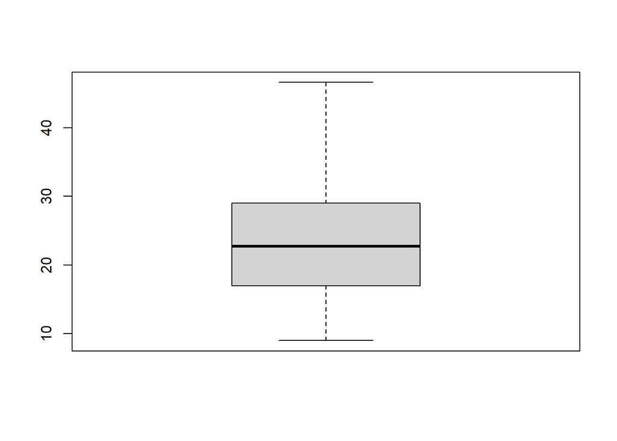

```r
boxplot(data_mpg$mpg)
```

plot boxplot anf find that acceleration have outlier

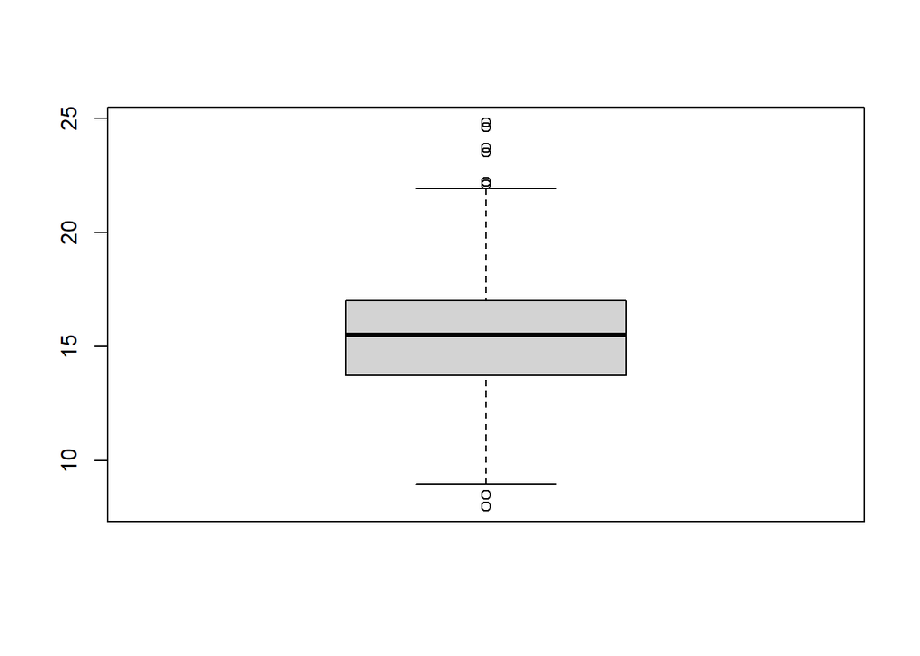

```r
boxplot(data_mpg$acceleration)
```

plot boxplot and find that horsepower have outlier

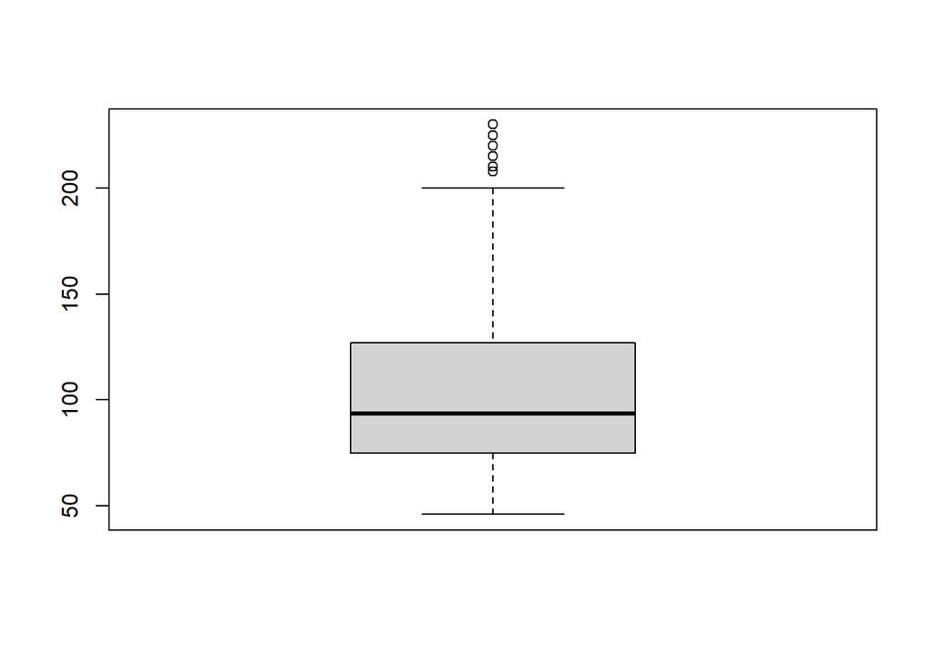

```r
boxplot(data_mpg$horsepower)
```

find outlier of horsepower

```r
quan=quantile(data_mpg$horsepower,c(0.25,0.5,0.75))
IQR_horsepower = quan[3]-quan[1]
outlier_horsepower=which(data_mpg$horsepower > quan[2]+1.5*IQR_horsepower)
data_mpg_outlier_horsepower = data_mpg[outlier_horsepower,]
```

find outlier of acceleration

```r
quan=quantile(data_mpg$acceleration,c(0.25,0.5,0.75))
IQR_acceleration = quan[3]-quan[1]
outlier_acceleration=which(data_mpg$acceleration > quan[2]+1.5*IQR_acceleration | data_mpg$acceleration < quan[2]-1.5*IQR_acceleration)
data_mpg_outlier_acceleration = data_mpg[outlier_acceleration,]
```

plot scatter plot of horsepower with mpg , although have outlier but it have small mpg

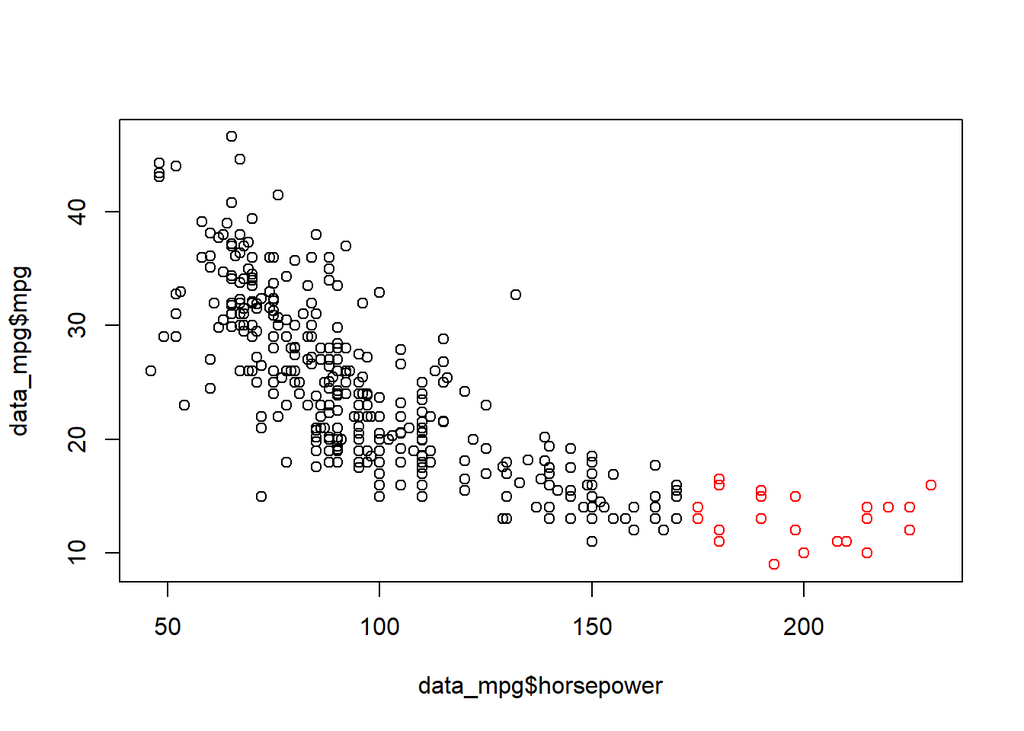

```r
plot(data_mpg$horsepower,data_mpg$mpg)
points(x=data_mpg_outlier_horsepower$horsepower,y=data_mpg_outlier_horsepower$mpg,col='red')
```

plot scatter plot of acceleration with mpg , although have outlier but when the acceleration small ,the mpg small , and when acceleration large mpg is irregular

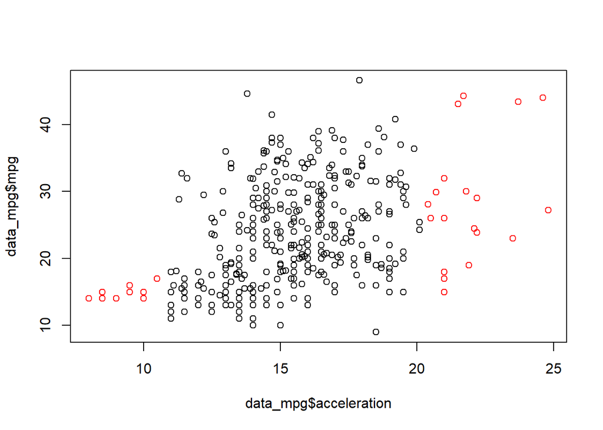

```r
plot(data_mpg$acceleration,data_mpg$mpg)
points(x=data_mpg_outlier_acceleration$acceleration,y=data_mpg_outlier_acceleration$mpg,col='red')
```

plot scatter plot of acceleration and horsepower

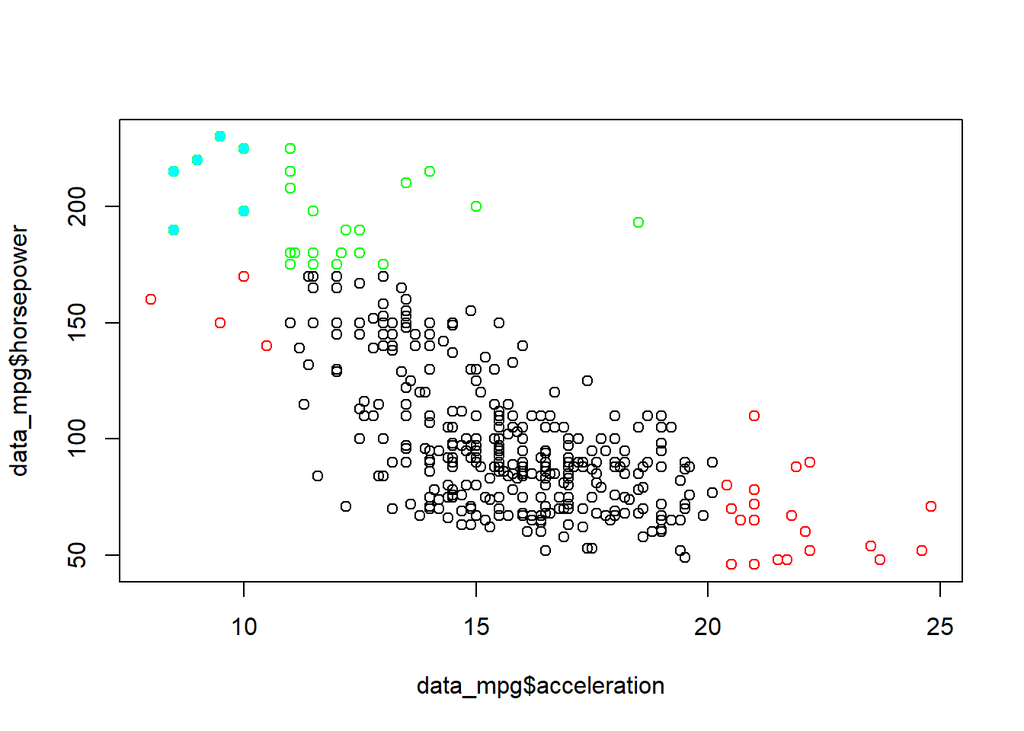

```r
plot(data_mpg$acceleration,data_mpg$horsepower)
points(x=data_mpg_outlier_acceleration$acceleration,y=data_mpg_outlier_acceleration$horsepower,col='red')
points(x=data_mpg_outlier_horsepower$acceleration,y=data_mpg_outlier_horsepower$horsepower,col='green')
outlier = intersect(outlier_acceleration , outlier_horsepower)
data_mpg_pool_outlier = data_mpg[outlier,]
points(x=data_mpg_pool_outlier$acceleration,y=data_mpg_pool_outlier$horsepower,col='cyan',pch=16)
```

plot boxplot of mpg group by cylinders , and find have outlier

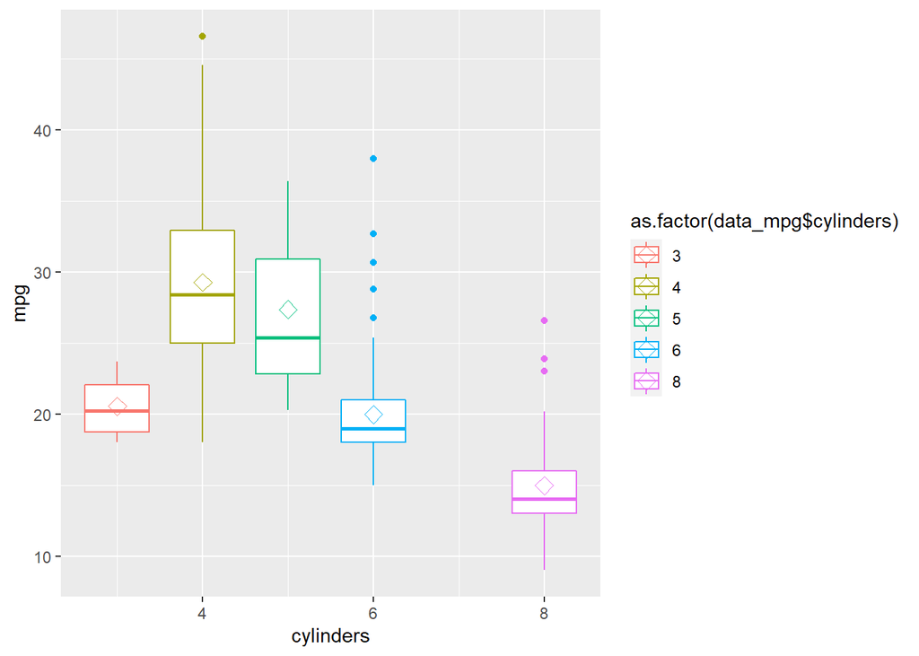

```r
data_mpg%>%
  ggplot(aes(cylinders,mpg ,color =as.factor(data_mpg$cylinders) ))+
  geom_boxplot()+
  stat_summary(fun.y=mean, geom="point", shape=5, size= 3)
```

plot boxplot of mpg group by origin, and find have outlier

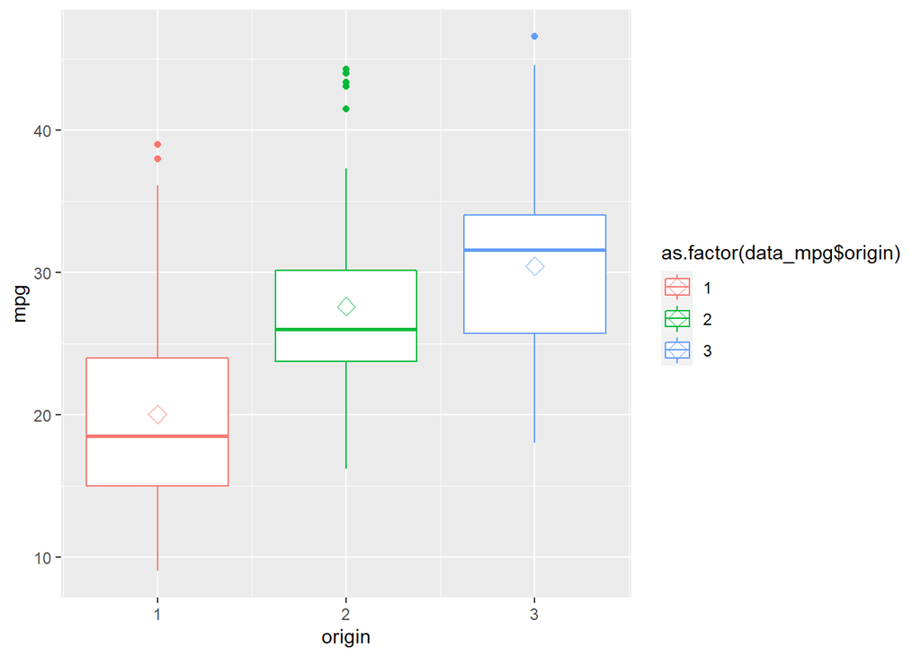

```r
data_mpg%>%
  ggplot(aes(origin,mpg ,color =as.factor(data_mpg$origin) ))+
  geom_boxplot()+
  stat_summary(fun.y=mean, geom="point", shape=5, size= 3)
```

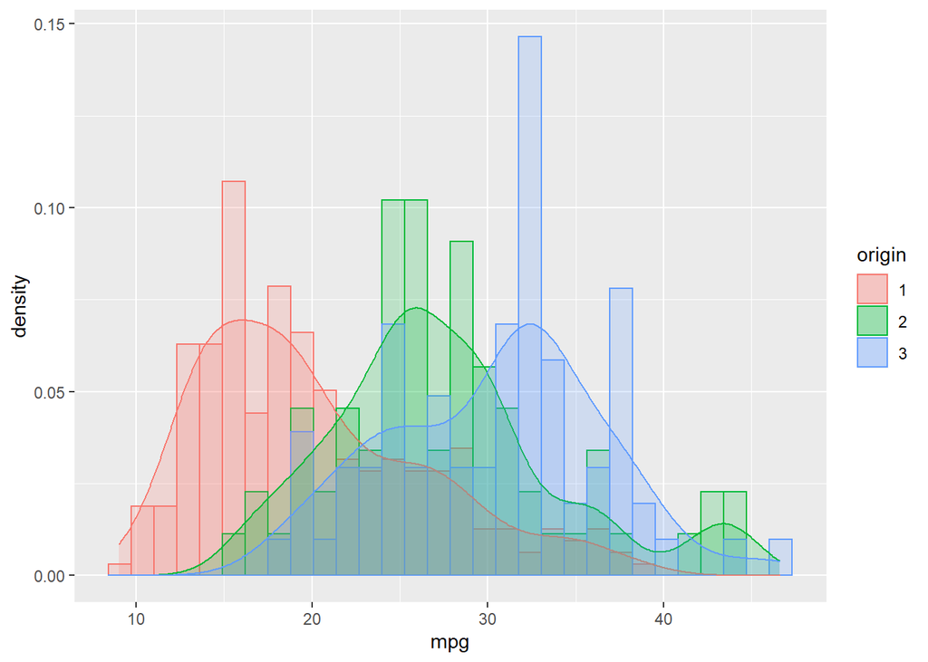

```r
data_mpg[['origin']]=as.character(data_mpg[['origin']])
ggplot(data_mpg,aes(x=mpg,group=origin,col=origin,fill=origin))+
  geom_histogram(aes(y=..density..),alpha=0.2,position="identity")+
  geom_density(alpha=0.2)
```

```r
data_mpg[['origin']]=as.numeric(data_mpg[['origin']])
```

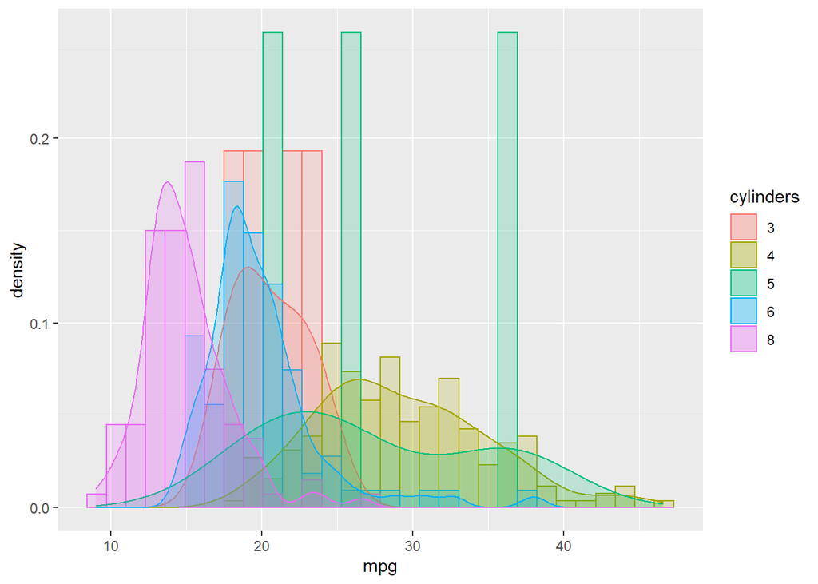

```r
data_mpg[['cylinders']]=as.character(data_mpg[['cylinders']])
ggplot(data_mpg,aes(x=mpg,group=cylinders,color=cylinders,fill=cylinders))+
  geom_histogram(aes(y=..density..),alpha=0.2,position="identity")+
  geom_density(alpha=0.2)
```

```r
data_mpg[['cylinders']]=as.numeric(data_mpg[['cylinders']])
```

find the displacement and weight have high association with mpg

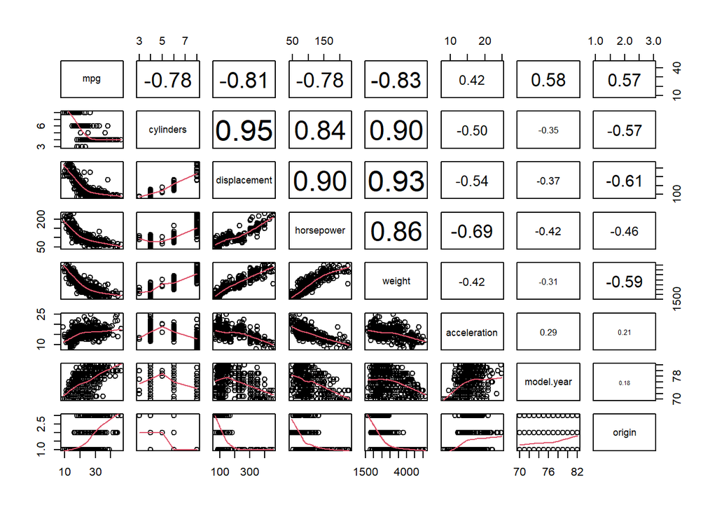

```r
panel.cor=function(x,y,digits=2,prefix="",cex.cor=10,...)
  {
  usr=par("usr")
  on.exit(par(usr))
  par(usr = c(0, 1, 0, 1))
  r=cor(x,y)
  txt=format(c(r,0.123456789),digits=digits)[1]
  txt=paste(prefix,txt,sep ="")
  if(missing(cex.cor)) cex.cor=1/strwidth(txt)
  text(0.5,0.5,txt,cex=cex.cor*abs(r))
  }
pairs(data_mpg,lower.panel=panel.smooth,upper.panel=panel.cor)
```

check distribution for mpg , and find that it is positive skew (i.e skew to right)

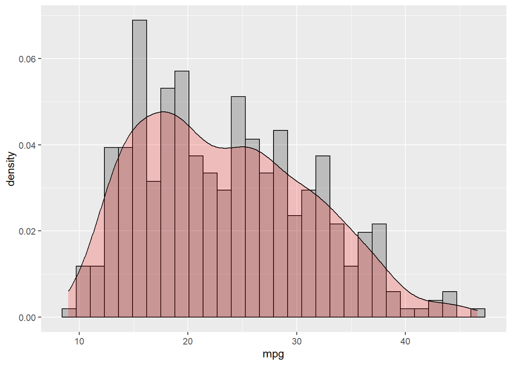

```r
data_mpg%>%
  ggplot(aes(mpg))+
  geom_histogram(aes(y=..density..),col='black',fill='black',alpha=0.2)+
  geom_density(alpha=0.2,fill='red')
```

```r
skewness(data_mpg$mpg)
```

```
## [1] 0.4553414
```

and we take log for mpg and find that symmetrical distribution

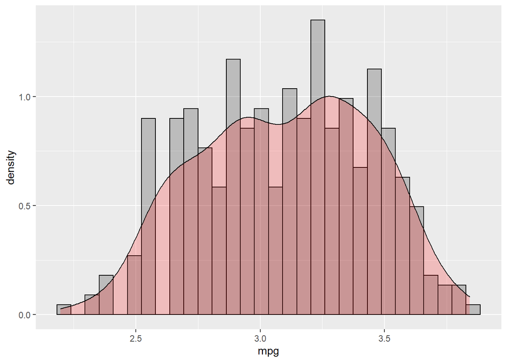

```r
data_mpg['mpg'] = log(data_mpg['mpg'])
data_mpg%>%
  ggplot(aes(mpg))+
  geom_histogram(aes(y=..density..),col='black',fill='black',alpha=0.2)+
  geom_density(alpha=0.2,fill='red')
```

if we take log for mpg , cylinders,displacement ,horsepower and weight will have high association with mpg

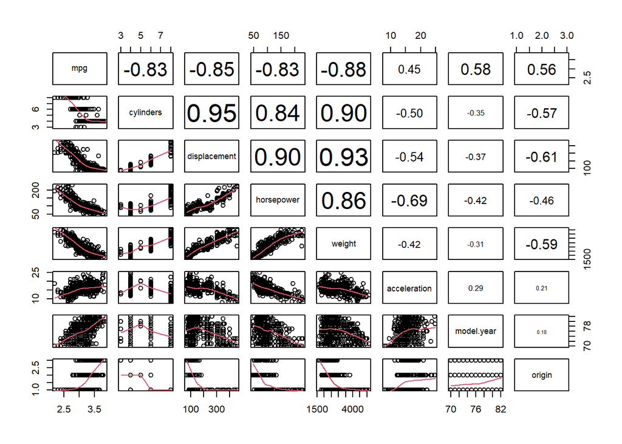

```r
pairs(data_mpg,lower.panel=panel.smooth,upper.panel=panel.cor)
```

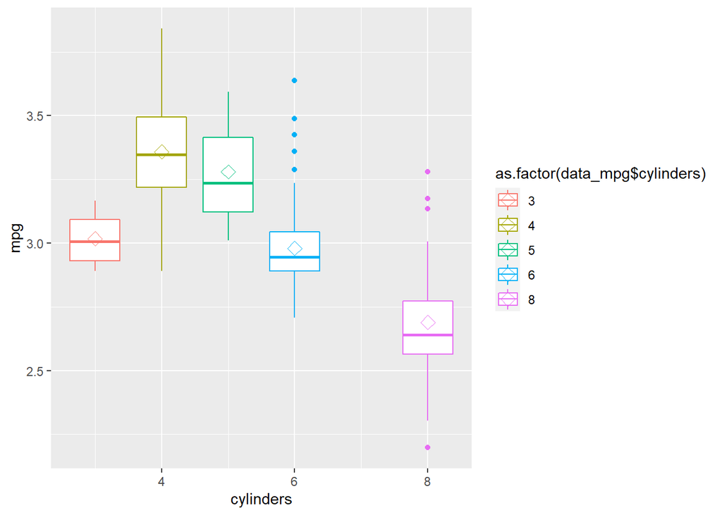

```r
data_mpg%>%
  ggplot(aes(cylinders,mpg ,color =as.factor(data_mpg$cylinders) ))+
  geom_boxplot()+
  stat_summary(fun.y=mean, geom="point", shape=5, size= 3)
```

compare previous boxplot the outlier are decrease

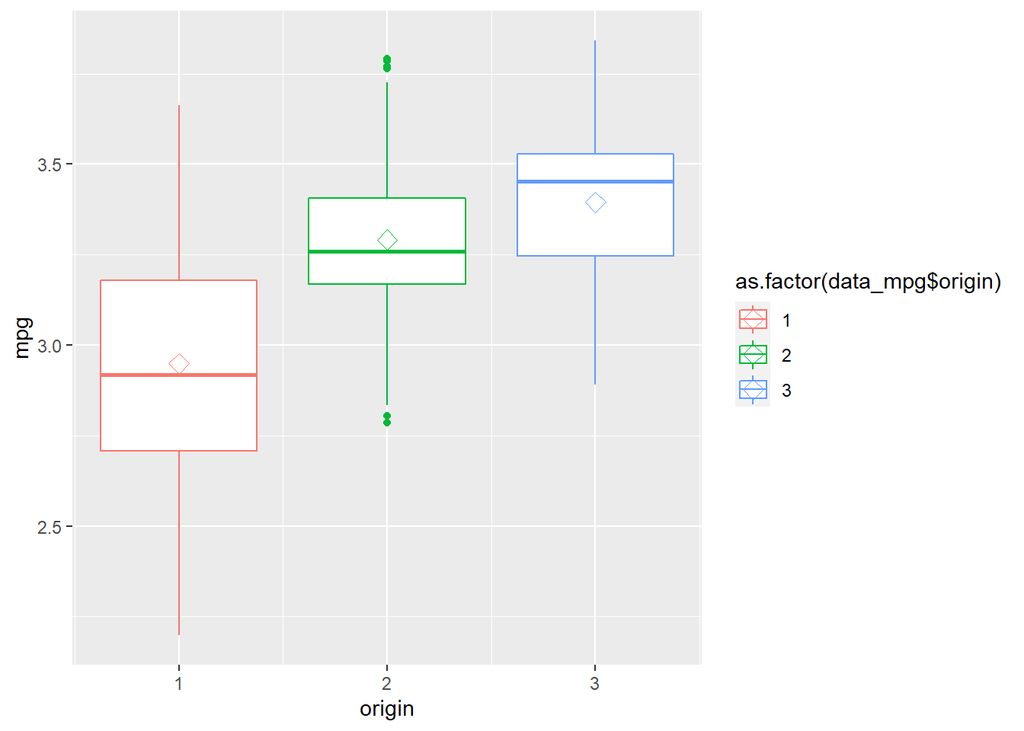

```r
data_mpg%>%
  ggplot(aes(origin,mpg ,color =as.factor(data_mpg$origin) ))+
  geom_boxplot()+
  stat_summary(fun.y=mean, geom="point", shape=5, size= 3)
```

compare previous plot

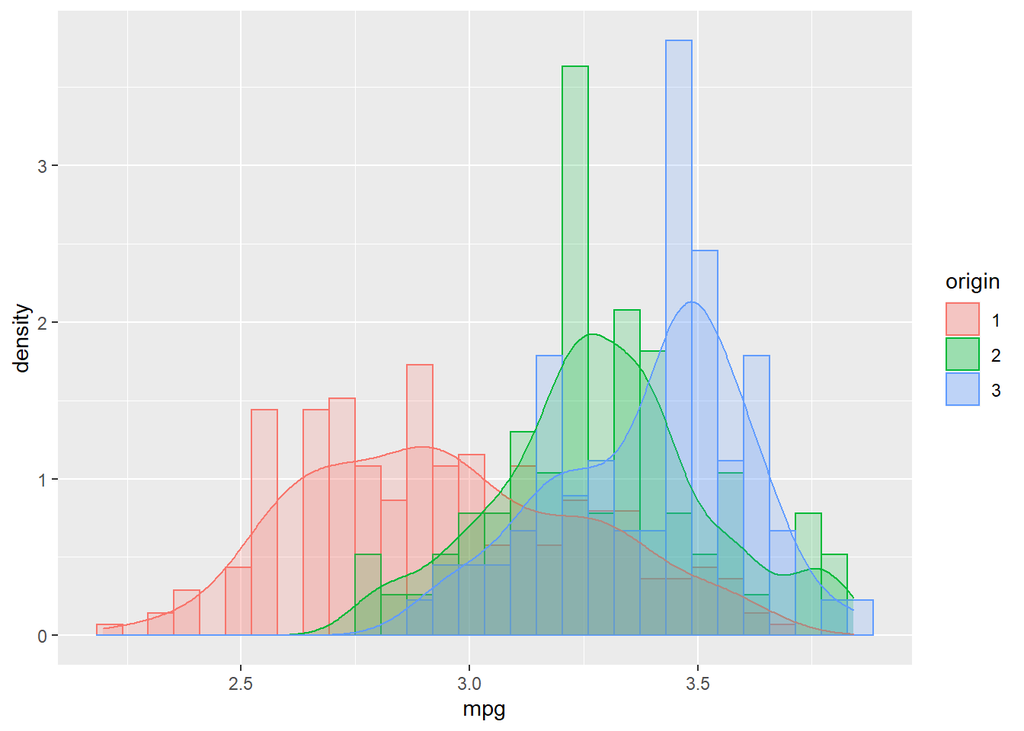

```r
data_mpg[['origin']]=as.character(data_mpg[['origin']])
ggplot(data_mpg,aes(x=mpg,group=origin,col=origin,fill=origin))+
  geom_histogram(aes(y=..density..),alpha=0.2,position="identity")+
  geom_density(alpha=0.2)
```

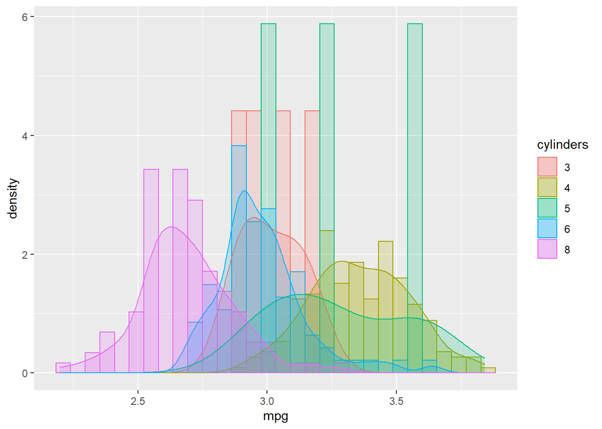

```r
data_mpg[['cylinders']]=as.character(data_mpg[['cylinders']])
ggplot(data_mpg,aes(x=mpg,group=cylinders,color=cylinders,fill=cylinders))+
  geom_histogram(aes(y=..density..),alpha=0.2,position="identity")+
  geom_density(alpha=0.2)
```

# Conclusion : 如果 outlier 跟趨勢差不多無需處理，如果跟趨勢有落差可以單獨拿出來探討，以此資料為例 horsepower跟mpg 成反比，若 outlier of horsepower 跟 mpg 成正比或不成反比 可以單獨討論。